# M1: Data Import

Day 1 — Introduction to Movement Ecology

Animal Movement Analyses for Ecologists | SYSU Shenzhen

# Learning Objectives

By the end of this module you will be able to:

1. Download animal tracking data directly from [Movebank](https://www.movebank.org/) using the `move2` package
2. Import data from a local CSV file as an alternative workflow
3. Understand the structure of a `move2` object
4. Perform initial exploration to understand your dataset

**Packages used:** `move2`, `tidyverse`, `lubridate`, `sf`, `mapview`, `units`, `gt`

# Introduction

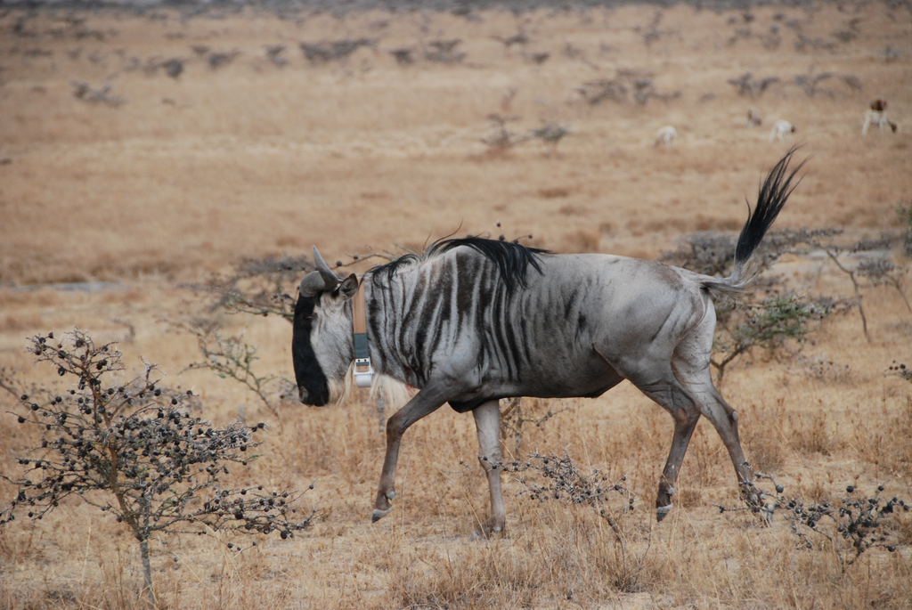

The data used in this exercise can be referenced as:

Stabach JA, Hughey LF, Crego RD, Fleming CH, Hopcraft JGC, Leimgruber P, Morrison TA, Ogutu JO, Reid RS, Worden JS, Boone RB. 2022. Increasing anthropogenic disturbance restricts wildebeest movement across East African grazing systems. Frontiers in Ecology and Evolution. doi.org/10.3389/fevo.2022.846171

Stabach JA, Hughey LF, Reid RS, Worden JS, Leimgruber P, Boone RB. 2020. Data from: Comparison of movement strategies of three populations of white-bearded wildebeest. Movebank Data Repository. [doi:10.5441/001/1.h0t27719](https://www.datarepository.movebank.org/handle/10255/move.1095)

## 1. Setup

As a first step, we will import the necessary packages to conduct our analysis. This requires clearing your console and loading the required libraries for analysis.

```r
# Clear R's memory
rm(list=ls())

# You may need to install these packages first
# install.packages(c("move2", "tidyverse", "lubridate", "sf", "mapview", "units", "gt"))

library(move2)       # Movebank interface and the move2 spatial data class
library(tidyverse)   # Data wrangling and visualization (dplyr, ggplot2, etc.)
library(lubridate)   # Working with timestamps and timezones
library(sf)          # Spatial vector data (move2 is built on sf)
library(mapview)     # Quick interactive maps
library(units)       # Provides support for measurement units
library(gt)          # Makes presentation-ready display tables
```

### 1.1 Setting the Time Zone and Coordinate System

Data in this example were collected in Kenya. Data stored in [Movebank](https://www.movebank.org/), however, are stored in UTC (Coordinated Universal Time). This is standard practice, but means that data need to be converted to local time (in this case, East Africa Time - EAT) prior to conducting analyses. A helpful [wiki](https://en.wikipedia.org/wiki/List_of_tz_database_time_zones) exists to help in choosing the appropriate timezone identifier for your particular study area.

Data collected via a GPS device must be encoded with an appropriate projection system to link the coordinates to specific locations on the earth’s surface. When you acquire or download geospatial data, make sure you know the projection of the data. This information is usually found in the metadata of a given dataset or should be provided by the person that is sharing the data with you.

It is important to recognize that projections try to minimize distortion of a 3-dimensional object (the earth) on a 2-dimensional surface (paper map or computer screen). Choosing a projection that minimizes this distortion is especially important when doing calculations of area or speed. It is recommended to collect all GPS data in geographic coordinates and project into a coordinate system that minimizes distortion of your objects of interest. The coordinate reference system (CRS) information needed to re-project your data are listed in http://spatialreference.org/ref/epsg/ and https://epsg.io/.

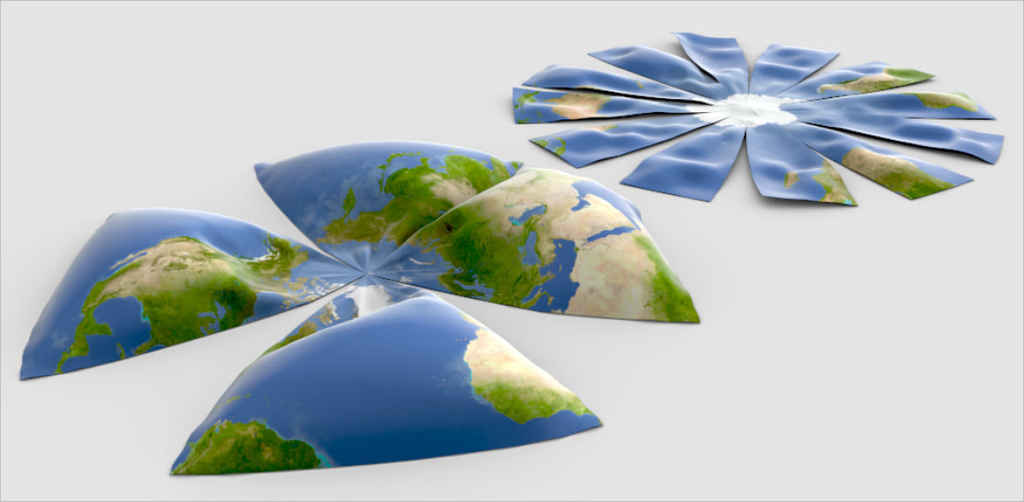

[Source: ESRI](https://www.esri.com/arcgis-blog/products/arcgis-pro/mapping/gcs_vs_pcs)

In this initial exercise, we will not project the data to a new coordinate system, instead keeping the dataset in its native format (i.e., decimal degrees). In future exercises, however, this will become an important topic for further discussion.

```r
# Set TimeZone
tz_utc <- "UTC"
tz_local <- "Africa/Nairobi"  # East Africa Time (EAT = UTC+3)

# Set Coordinate System
latlong_crs <- "EPSG:4326"   # WGS84 geographic — standard for GPS and Movebank
```

## 2. Downloading Data

We will demonstrate two methods for downloading data for analysis. In the first method, data are downloaded directly from [Movebank](https://www.movebank.org). In the second, data are downloaded from a .csv file. Both approaches produce the same end result. However, downloading data from [Movebank](https://www.movebank.org) offers additional advantages by providing a standardized data structure and enabling access to data that are continuously updated as new data are collected.

### 2.2 Movebank

[Movebank](https://www.movebank.org) is the world’s largest repository of animal tracking data, hosting data for thousands of studies across various taxa. The `move2` package provides a direct interface to [Movebank](https://www.movebank.org), allowing you to download data directly into [R](https://cran.r-project.org/) for analysis.

#### 2.2.1 Store your Credentials (Once per Computer)

Provide your credentials to access the [Movebank](https://www.movebank.org) API.

```r
# Run this once — credentials are stored securely in your system keychain
movebank_store_credentials("your_username", "your_password")
```

> **Security note:** Never hardcode your password in a script that you share or commit to GitHub. `movebank_store_credentials()` stores it once in your Operating System (OS) keychain. After saving once, `move2` functions will use it automatically.

#### 2.2.2 Explore Available Studies (optional)

See what’s available on [Movebank](https://www.movebank.org) that is publicly accessible. This is often more easily accomplished by logging on to [Movebank](https://www.movebank.org) and using the online interface.

```r
# Search for open-data studies that you can download data from
movebank_download_study_info(
  license_type = "CC_0",
  i_have_download_access = TRUE,
  attributes = c("name", "id")
)
```

##### 2.2.3 Wildebeest Data Download

Use the function `movebank_download_study()` and specify the ID to download the wildebeest data from [Movebank](https://www.movebank.org).

```r
WB.mv2 <- movebank_download_study(
  study_id = 208413731 # Use the Movebank ID or the Study Name
  #study_id = "White-bearded wildebeest (Connochaetes taurinus) movements - Kenya"
)

# You may be prompted to accept the data license. If so, you can append the license number to your code and run again, like this:
# WB.mv2 <- movebank_download_study(
#   study_id = 208413731,
#   #study_id = "White-bearded wildebeest (Connochaetes taurinus) movements - Kenya"
#   'license-md5'='xxxxxx' # <- copy license number here
# )
```

For these exercises, we will load a pre-downloaded version to avoid delays. This object is identical to what `movebank_download_study()` would return.

```r
# Load
load("./Data/wildebeest_data.rdata")
```

### 2.3 CSV Import

If you are unable to connect to [Movebank](https://www.movebank.org) or if your data exists elsewhere, you can import from a .CSV and convert to a `move2` object using `mt_as_move2()`. Make sure you force the ‘timestamp’ field to be read as raw text (‘col_character’), rather than letting `read_csv()` set the datetime. Always verify that the timestamp was imported properly.

```r
# Import file, changing the date format (formatted here as ymd_hms()) to match your dataset
WB.csv <- read_csv("Data/WB_FullDataset.csv",
                   col_types = cols(timestamp = col_character())) %>%
  mutate(timestamp = ymd_hms(timestamp, tz = tz_utc))

# Always verify the timestap before moving on
# The result of this query should be 0:
# sum(is.na(WB.csv$timestamp))

# Convert to move2 object
WB.csv <- mt_as_move2(WB.csv, # Note that I am overwriting the original WB.csv file
                      coords = c("longitude", "latitude"),  # column names for x, y
                      crs = latlong_crs,
                      time_column = "timestamp",
                      track_id_column  = "individual_local_identifier"
                      )

# Note, the reference information was not imported, although it is provided in the Data directory (Data/wildebeest_ref.csv).  If imported, the dataframe would need to be joined to the original by a common field.  This could be easily accomplished using the `left_join()` function on a shared field (e.g., ID).
```

> **Note:** `mt_as_move2()` works with any dataframe that has coordinates and timestamps. Once converted, the object behaves identical to a Movebank download — all the same `mt_*` functions apply.

## 3. Understanding the Move2 Object

`Move2` is a relatively new package (2022) designed to make working with tracking data more intuitive. A `move2` object is fundamentally an `sf` (simple features) object — meaning every row already includes a spatial point geometry — with extra structure to handle multiple individuals and timestamps. Using `move2` will be useful as we explore other analyses that have been developed to work with this library, but can be confusing if you are more comfortable working with dataframes.

### 3.1 Data Summary

`Move2` includes various functions that have been developed to provide summary information, such as the number of tracks, the time range of data collection, the coordinate reference system, and a general preview of the data.

```r
# Print the move2 object class
class(WB.mv2)   # move2, sf, tbl_df, tbl, data.frame
```

```
## [1] "move2"       "sf"          "spec_tbl_df" "tbl_df"      "tbl"
## [6] "data.frame"
```

```r
# Print a structured summary
WB.mv2
```

```
## A <move2> with `track_id_column` "individual_local_identifier" and
## `time_column` "timestamp"
## Containing 36 tracks lasting on average 509 days in a
## Simple feature collection with 276706 features and 10 fields
## Geometry type: POINT
## Dimension:     XY
## Bounding box:  xmin: 34.80902 ymin: -2.957671 xmax: 37.71177 ymax: -1.114714
## Geodetic CRS:  WGS 84
## # A tibble: 276,706 × 11
##    sensor_type_id individual_local_identifier external_temperature gps_dop
##           <int64> <fct>                                       [°C]     [1]
##  1            653 Fifteen                                       17     3.6
##  2            653 Fifteen                                       20     7.2
##  3            653 Fifteen                                       21     4
##  4            653 Fifteen                                       22     3
##  5            653 Fifteen                                       25     2.2
##  6            653 Fifteen                                       25     3.2
##  7            653 Fifteen                                       25     4.2
##  8            653 Fifteen                                       27     1.4
##  9            653 Fifteen                                       27     2
## 10            653 Fifteen                                       26     2.2
## # ℹ 276,696 more rows
## # ℹ 7 more variables: gps_fix_type_raw <fct>, height_above_ellipsoid [m],
## #   tag_voltage [mV], timestamp <dttm>, event_id <int64>, visible <lgl>,
## #   geometry <POINT [°]>
## First 10 track features:
## # A tibble: 36 × 54
##    deployment_id     tag_id individual_id animal_life_stage attachment_type
##          <int64>    <int64>       <int64> <fct>             <fct>
##  1    3568311116 3568311048    3568311014 9 years           collar
##  2    3571504300 3568311049    3568311016 10 years          collar
##  3    3568311120 3568311050    3568311002 5 years           collar
##  4    3568311112 3568311051    3568311015 8 years           collar
##  5    3568311122 3568311052    3568311005 7 years           collar
##  6    3568311134 3568311053    3568311017 7 years           collar
##  7    3568311103 3568311054    3568311013 10 years          collar
##  8    3568311115 3568311055    3568311000 9 years           collar
##  9    3568311098 3568311056    3568311009 9 years           collar
## 10    3568311124 3568311057    3568311025 12 years          collar
## # ℹ 26 more rows
## # ℹ 49 more variables: deploy_off_timestamp <dttm>, deploy_on_timestamp <dttm>,
## #   deployment_end_comments <chr>, duty_cycle <chr>,
## #   deployment_local_identifier <fct>, study_site <chr>, sensor_type_ids <chr>,
## #   capture_location <POINT [°]>, deploy_on_location <POINT [°]>,
## #   deploy_off_location <POINT [°]>, death_comments <chr>,
## #   individual_local_identifier <fct>, sex <fct>, taxon_canonical_name <fct>, …
```

```r
# Print the number of unique animals by accessing the track_id column.
n_distinct(mt_track_id(WB.mv2)) # n_distinct is the same as length(unique(mt_track_id(WB.mv2))), but easier to write and understand
```

```
## [1] 36
```

```r
# Print the number of unique tracks
mt_n_tracks(WB.mv2)
```

```
## [1] 36
```

```r
# Print the name of the timestamp column
mt_time_column(WB.mv2)
```

```
## [1] "timestamp"
```

```r
# Print the name of the track ID column
mt_track_id_column(WB.mv2)
```

```
## [1] "individual_local_identifier"
```

```r
# Overall time range
range(mt_time(WB.mv2), na.rm = TRUE)
```

```
## [1] "2010-05-25 18:01:00 UTC" "2012-12-04 15:00:00 UTC"
```

### 3.2 Event Data vs Track Metadata

A `move2` object holds two distinct types of information:

1. Event data: One row per GPS fix — location, timestamp, sensor readings
2. Track metadata: One row per individual — sex, deployment dates, study site

```r
# mt_track_data() returns a data.frame containing the track attribute data
# glimpse() can then be used to provide a brief summary (a transposed version of print())
track_info <- mt_track_data(WB.mv2)
glimpse(track_info)
```

```
## Rows: 36
## Columns: 54
## $ deployment_id                     <int64> 3568311116, 3571504300, 3568311120…
## $ tag_id                            <int64> 3568311048, 3568311049, 3568311050…
## $ individual_id                     <int64> 3568311014, 3568311016, 3568311002…
## $ animal_life_stage                 <fct> 9 years, 10 years, 5 years, 8 years,…
## $ attachment_type                   <fct> collar, collar, collar, collar, coll…
## $ deploy_off_timestamp              <dttm> 2012-06-21 23:59:00, 2010-08-18 23:…
## $ deploy_on_timestamp               <dttm> 2010-05-28, 2010-05-28, 2010-05-26,…
## $ deployment_end_comments           <chr> "fate unknown", "predated", "fate un…
## $ duty_cycle                        <chr> "16 fixes/day: hourly 06:00-18:00; 3…
## $ deployment_local_identifier       <fct> 2829_Naboisho, 2830_Naiba, 2831_Kayi…
## $ study_site                        <chr> "Mara", "Mara", "Mara", "Mara", "Mar…
## $ sensor_type_ids                   <chr> "gps", "gps", "gps", "gps", "gps", "…
## $ capture_location                  <POINT [°]> POINT EMPTY, POINT EMPTY, POIN…
```

[output cut: 41 more lines]

```r
# Or just look at the column names from the event data
names(WB.mv2) # Same as colnames(WB.mv2)
```

```
##  [1] "sensor_type_id"              "individual_local_identifier"
##  [3] "external_temperature"        "gps_dop"
##  [5] "gps_fix_type_raw"            "height_above_ellipsoid"
##  [7] "tag_voltage"                 "timestamp"
##  [9] "event_id"                    "visible"
## [11] "geometry"
```

> When you download from Movebank with `move2`, the deployment metadata (e.g., individual info, study site, sex, deploy on/off dates) is automatically embedded in the track data. In Module 2, we will use this information to subset to the study area and filter by deployment period.

## 4. Data Exploration

To explore the basic properties of the dataset, such as querying the dimensions and structure of the data collected, many base [R](https://www.r-project.org/) functions can be used.

```r
nrow(WB.mv2) # Total number of rows in the dataset
```

```
## [1] 276706
```

```r
ncol(WB.mv2) # Total number of columns in the dataset
```

```
## [1] 11
```

```r
dim(WB.mv2) # Total number of rows and columns
```

```
## [1] 276706     11
```

```r
glimpse(WB.mv2) # Get a quick view of each column
```

```
## Rows: 276,706
## Columns: 11
## $ sensor_type_id              <int64> 653, 653, 653, 653, 653, 653, 653, 653, …
## $ individual_local_identifier <fct> Fifteen, Fifteen, Fifteen, Fifteen, Fiftee…
## $ external_temperature        [°C] 17 [°C], 20 [°C], 21 [°C], 22 [°C], 25 [°C]…
## $ gps_dop                     [1] 3.6 [1], 7.2 [1], 4.0 [1], 3.0 [1], 2.2 [1],…
## $ gps_fix_type_raw            <fct> 3D, 3D, 3D, 3D, 3D, 3D, 3D, 3D, 3D, 3D, 3D…
## $ height_above_ellipsoid      [m] 1868.23 [m], 1859.33 [m], 1845.95 [m], 1855.…
## $ tag_voltage                 [mV] NA [mV], NA [mV], NA [mV], NA [mV], NA [mV]…
## $ timestamp                   <dttm> 2010-05-30 05:00:00, 2010-05-30 06:00:00,…
## $ event_id                    <int64> 32441006811, 32441006826, 32441006840, 3…
## $ visible                     <lgl> TRUE, TRUE, TRUE, TRUE, TRUE, TRUE, TRUE, …
## $ geometry                    <POINT [°]> POINT (35.686 -1.277267), POINT (35.…
```

### 4.1 Per-individual Summary

We can also use the `summarise()` function to create a query of the data collected, summarizing how many fixes were collected for each animal and for what period of time.

```r
wb.Summary <- WB.mv2 %>%
  as_tibble() %>%
  summarise(Locations = n(),
            Start = min(timestamp, na.rm = TRUE),
            End = max(timestamp, na.rm = TRUE),
            Duration = round(as.numeric(difftime(max(timestamp, na.rm = TRUE),
                                                   min(timestamp, na.rm = TRUE),
                                                   units = "days")), digits = 1),
            .by = individual_local_identifier) %>%
  arrange(individual_local_identifier)

# Print Results
wb.Summary
```

```
## # A tibble: 36 × 5
##    individual_local_identifier Locations Start               End
##    <fct>                           <int> <dttm>              <dttm>
##  1 Fifteen                         11761 2010-05-30 05:00:00 2012-10-14 14:03:00
##  2 Karbolo                          6103 2010-10-19 00:00:00 2011-12-08 08:02:00
##  3 Kayioni                         11452 2010-05-26 00:00:00 2012-06-13 15:00:00
##  4 Kikaya                          10996 2010-10-20 21:01:00 2012-10-17 06:01:00
##  5 Kiranto                         11981 2010-10-17 13:00:00 2012-12-04 15:00:00
##  6 Koyiaki                          4433 2010-05-28 04:00:00 2011-03-18 15:01:00
##  7 Laingoni                         7826 2010-10-15 18:01:00 2012-03-17 15:00:00
##  8 Ledama                           7213 2010-05-26 03:00:00 2011-09-27 00:00:00
##  9 Lempaash                         4150 2010-10-11 04:00:00 2011-07-08 03:00:00
## 10 Lengaruani                       8537 2010-10-11 18:01:00 2012-06-10 18:03:00
## # ℹ 26 more rows
## # ℹ 1 more variable: Duration <dbl>
```

```r
# Now make a prettier table and output the file
gt_gnu <- wb.Summary %>%

  # initialize gt table
  gt() %>%

  # Make the table easier to read with alternating grey bars
  opt_row_striping() %>%

  # Add title and subtitle, pulling date of creation
  tab_header(
    title = "White-bearded Wildebeest in Kenya: Tracking Data Summary",
    subtitle = paste0("Created: ",Sys.Date())) %>%

  # Easy preset date formatting
  fmt_date(
    columns = c(Start, End),
    date_style = 8) %>%

  # Change the column labels for the table
  cols_label(individual_local_identifier = "Wildebeest ID",
             Locations = "Total points",
             Start = "First location",
             End = "Last location",
             Duration = "Tracking period (days)") %>%

  # Center text inside columns
  cols_align(align = "center")

# Print result
gt_gnu
```

White-bearded Wildebeest in Kenya: Tracking Data Summary

Created: 2026-07-27

| Wildebeest ID | Total points | First location | Last location | Tracking period (days) |
| --- | --- | --- | --- | --- |
| Fifteen | 11761 | 30 May 2010 | 14 October 2012 | 868.4 |
| Karbolo | 6103 | 19 October 2010 | 8 December 2011 | 415.3 |
| Kayioni | 11452 | 26 May 2010 | 13 June 2012 | 749.6 |
| Kikaya | 10996 | 20 October 2010 | 17 October 2012 | 727.4 |
| Kiranto | 11981 | 17 October 2010 | 4 December 2012 | 779.1 |
| Koyiaki | 4433 | 28 May 2010 | 18 March 2011 | 294.5 |
| Laingoni | 7826 | 15 October 2010 | 17 March 2012 | 518.9 |
| Ledama | 7213 | 26 May 2010 | 27 September 2011 | 488.9 |
| Lempaash | 4150 | 11 October 2010 | 8 July 2011 | 270.0 |
| Lengaruani | 8537 | 11 October 2010 | 10 June 2012 | 608.0 |
| Leporana | 3549 | 12 October 2010 | 31 May 2011 | 231.9 |
| Lerisa | 1002 | 10 October 2010 | 12 December 2010 | 62.7 |
| Motorogi | 2856 | 26 May 2010 | 24 November 2010 | 181.2 |
| Naboisho | 11565 | 28 May 2010 | 21 June 2012 | 755.1 |
| Nagol | 14174 | 27 May 2010 | 4 December 2012 | 921.8 |
| Naiba | 1314 | 28 May 2010 | 17 August 2010 | 81.8 |
| Naisula | 8743 | 30 May 2010 | 18 December 2011 | 567.3 |
| Naserian | 14244 | 27 May 2010 | 4 December 2012 | 921.9 |
| Ne Mpaash | 7357 | 16 October 2010 | 5 February 2012 | 476.5 |
| Neatoo | 11126 | 29 May 2010 | 24 May 2012 | 726.6 |
| Nenkitirua | 11588 | 11 October 2010 | 29 October 2012 | 748.5 |
| Nenkongu Narok | 1948 | 11 October 2010 | 16 February 2011 | 127.4 |
| Nentepesi | 12089 | 10 October 2010 | 4 December 2012 | 786.2 |
| Nesimei | 8023 | 10 October 2010 | 7 April 2012 | 544.5 |
| Nkairowua | 4336 | 29 May 2010 | 12 March 2011 | 286.8 |
| Nkoko | 4652 | 27 May 2010 | 28 March 2011 | 305.4 |
| Noontare | 11124 | 16 October 2010 | 2 December 2012 | 778.1 |
| Ntishya | 11843 | 19 October 2010 | 20 November 2012 | 763.2 |
| Ole Nagol | 1111 | 16 October 2010 | 24 December 2010 | 69.3 |
| Olope | 6866 | 25 May 2010 | 11 August 2011 | 442.2 |
| Paita | 11119 | 18 October 2010 | 18 October 2012 | 731.3 |
| Peria | 11842 | 19 October 2010 | 3 December 2012 | 776.4 |
| Reiyo | 11131 | 12 October 2010 | 8 October 2012 | 726.9 |
| Sawani | 3588 | 20 October 2010 | 13 June 2011 | 236.3 |
| Sotua | 4820 | 15 October 2010 | 13 September 2011 | 332.7 |
| Taletian | 244 | 29 May 2010 | 14 June 2010 | 16.4 |

```r
# Save as html table to send to the project manager, or a shiny app
gtsave(gt_gnu, filename = "Output/summary_gnu.html")
```

> **Discussion:** Notice the variation in tracking duration and number of fixes across individuals. This kind of imbalance is common in real tracking datasets and has implications for comparative analyses. What might cause an individual to have fewer fixes than others?

### 4.2 Sampling interval

Many movement analyses assume a regular sampling interval (or at least close to regular). It is important to understand your data’s fix rate distribution before proceeding. Here we will calculate the time between consecutive fixes for each animal and summarize results as a histogram.

```r
# mt_time_lags() returns the time difference to the NEXT location for each row in the dataset
time_lags <- WB.mv2 %>%
  arrange(individual_local_identifier, timestamp) %>%
  mutate(dt_hours = mt_time_lags(.) %>% # A function to retrieve the interval duration between locations, defaults to minutes
           set_units("hours") %>%  # convert to hours
           as.numeric()) %>% # Make the field numeric
  as_tibble()

# Notice the "dt_hours" column
head(time_lags)
```

```
## # A tibble: 6 × 12
##   sensor_type_id individual_local_identifier external_temperature gps_dop
##          <int64> <fct>                                       [°C]     [1]
## 1            653 Fifteen                                       17     3.6
## 2            653 Fifteen                                       20     7.2
## 3            653 Fifteen                                       21     4
## 4            653 Fifteen                                       22     3
## 5            653 Fifteen                                       25     2.2
## 6            653 Fifteen                                       25     3.2
## # ℹ 8 more variables: gps_fix_type_raw <fct>, height_above_ellipsoid [m],
## #   tag_voltage [mV], timestamp <dttm>, event_id <int64>, visible <lgl>,
## #   geometry <POINT [°]>, dt_hours <dbl>
```

```r
# The last time lag of each individual track will always be NA, so the total NA should be equal to the number of individuals
sum(is.na(time_lags$dt_hours))  == n_distinct(time_lags$individual_local_identifier)
```

```
## [1] TRUE
```

```r
# Use filter to remove these NA values
time_lags <- time_lags %>%
  filter(!is.na(dt_hours))

# What is the nominal sampling interval? Different tags/studies/species can have very different fix schedules.
target_interval_h <- round(median(time_lags$dt_hours), 1)
cat("Empirical (median) sampling interval across all individuals:", target_interval_h, "hour\n")
```

```
## Empirical (median) sampling interval across all individuals: 1 hour
```

```r
# Summary of sampling intervals per individual
time_lags %>%
  summarise(
    median_interval_h = round(median(dt_hours), 2),
    min_interval_h = round(min(dt_hours), 2),
    max_interval_h = round(max(dt_hours), 2),
    pct_irregular = round(mean(abs(dt_hours - target_interval_h) > 0.1) * 100, 1), # Calculate the percent irregular from the median value calculated
    .by = individual_local_identifier
  )
```

```
## # A tibble: 36 × 5
##    individual_local_identifier median_interval_h min_interval_h max_interval_h
##    <fct>                                   <dbl>          <dbl>          <dbl>
##  1 Fifteen                                     1           0.08           394.
##  2 Karbolo                                     1           0.02           193.
##  3 Kayioni                                     1           0.03           194
##  4 Kikaya                                      1           0.02           217
##  5 Kiranto                                     1           0.02           211
##  6 Koyiaki                                     1           0.08           225.
##  7 Laingoni                                    1           0.02           211
##  8 Ledama                                      1           0.02           229
##  9 Lempaash                                    1           0.05           213
## 10 Lengaruani                                  1           0.02           254.
## # ℹ 26 more rows
## # ℹ 1 more variable: pct_irregular <dbl>
```

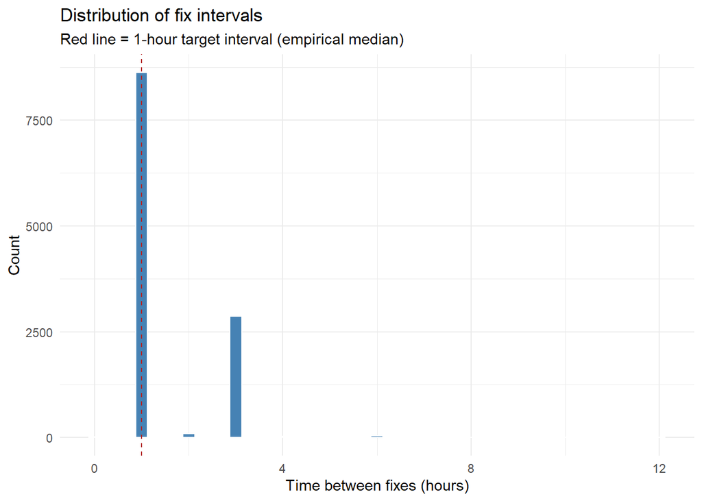

```r
# Graph the interval distribution for one individual
time_lags %>%
  filter(individual_local_identifier == first(individual_local_identifier), # Could change this to a different individual or create a loop to print result for every individual
         dt_hours < 12) %>%
  ggplot(aes(x = dt_hours)) +
  geom_histogram(binwidth = 0.25, fill = "steelblue", color = "white") +
  geom_vline(xintercept = target_interval_h, color = "firebrick", linetype = "dashed") +
  labs(title = "Distribution of fix intervals",
       subtitle = paste0("Red line = ", target_interval_h, "-hour target interval (empirical median)"),
       x = "Time between fixes (hours)", y = "Count") +
  theme_minimal()
```

This graph shows that the sampling intervals peak at 1 and 3 hours. In this case, the resulting sampling interval is by design - Wildebeest are more active during the day. As a result, collars were programmed to collect hourly fixes during daylight hours and every 3 hours at night, a duty cycle that collects relatively high resolution data during the day while saving battery overnight. We can check that this two-peak pattern really does line up with time of day, rather than just being an artifact of the histogram’s binning.

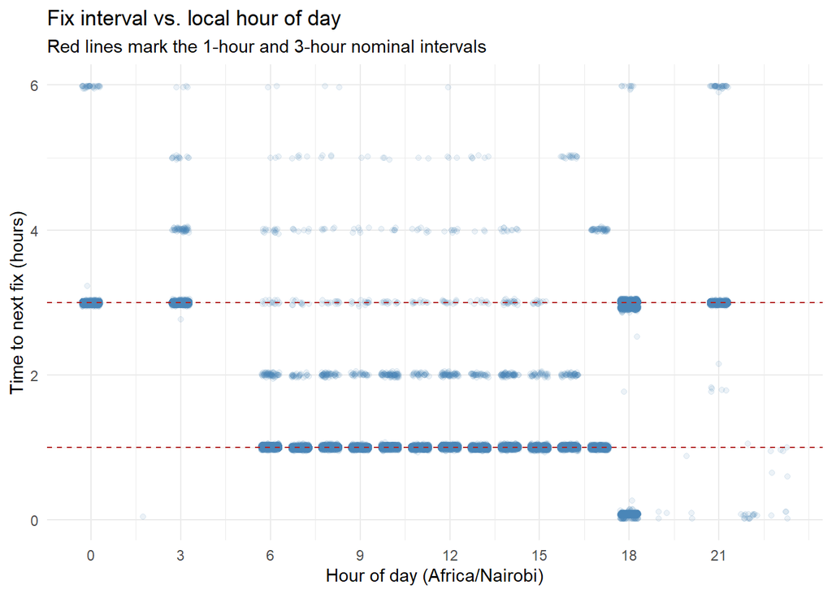

```r
# Pull out the hour of the timestamp using the hour() function, converting the result to local time.
# Check to see if (~1h) vs. long (~3h) intervals separate by time of day.
time_lags <- time_lags %>%
  mutate(hour_local = hour(with_tz(timestamp, tz_local)))

time_lags %>%
  filter(dt_hours < 6) %>%
  ggplot(aes(x = hour_local, y = dt_hours)) +
  geom_jitter(alpha = 0.1, width = 0.3, height = 0, color = "steelblue") +
  geom_hline(yintercept = c(1, 3), color = "firebrick", linetype = "dashed") +
  scale_x_continuous(breaks = seq(0, 23, 3)) +
  labs(title = "Fix interval vs. local hour of day",
       subtitle = "Red lines mark the 1-hour and 3-hour nominal intervals",
       x = "Hour of day (Africa/Nairobi)", y = "Time to next fix (hours)") +
  theme_minimal()
```

The ~1-hour intervals cluster during daylight hours and the ~3-hour intervals cluster overnight, confirming the duty cycle described. Not every irregularity in tracking data is designed, however.

A single `max_interval_h` will almost always look alarming. Over a multi-year deployment, nearly every individual will have some unusually long gap somewhere in its track. This isn’t necessarily evidence of a problem. The more useful question is *whether long gaps are isolated to a single tag or shared across many individuals at the same time*. An isolated gap on one animal, on a random date, points to a tag- or animal-specific cause (e.g., battery issue, poor satellite geometry, dense forest cover). The same gap appearing on many animals at once, all resolving within the same few days, points to a system-wide cause, such as a ground-station/uplink outage or a network-wide duty-cycle change.

```r
# Flag long gaps (> 1 day) and ask: Are these gaps spread randomly across individuals and dates? Or, do many individuals lose/regain signal together?
gap_threshold_h <- 24

long_gaps <- time_lags %>%
  filter(dt_hours > gap_threshold_h) %>% # Investigate all records where the time lag is > 24 hours
  mutate(gap_start = timestamp,                       # last fix before signal was lost
         gap_end   = timestamp + dhours(dt_hours)) %>% # first fix after signal returned
  select(individual_local_identifier, gap_start, gap_end, dt_hours)

cat(nrow(long_gaps), "gaps longer than", gap_threshold_h, "hours, across",
    n_distinct(long_gaps$individual_local_identifier), "of",
    n_distinct(time_lags$individual_local_identifier), "individuals\n")
```

```
## 218 gaps longer than 24 hours, across 31 of 36 individuals
```

```r
# Bin gap *resolutions* (gap_end) by week: a spike in the number of distinct individuals resolving a long gap in the same week is the signature of a synchronized, fleet-wide event rather than independent tag failures.
synchronized_gaps <- long_gaps %>%
  mutate(resume_week = floor_date(gap_end, "week")) %>% # Floor_date rounds down to the nearest boundary of the time unit
  group_by(resume_week) %>%
  summarise(n_individuals_affected = n_distinct(individual_local_identifier),
            n_gaps = n(), .groups = "drop") %>%
  arrange(desc(n_individuals_affected))

# Display the first 6 rows
head(synchronized_gaps)
```

```
## # A tibble: 6 × 3
##   resume_week         n_individuals_affected n_gaps
##   <dttm>                               <int>  <int>
## 1 2011-10-02 00:00:00                     19     21
## 2 2011-03-13 00:00:00                     18     18
## 3 2011-10-16 00:00:00                     17     17
## 4 2012-05-27 00:00:00                     13     17
## 5 2010-08-29 00:00:00                     12     12
## 6 2011-03-06 00:00:00                     11     11
```

We can also investigate the date when most individuals were impacted by a system-wide outage, using a conditional statement to evaluate if the instance was isolated. Here, we take one step beyond the previous summary to query how many individuals were impacted and within what time period.

```r
# Treat the week with the most individuals affected as a candidate system-wide outage (require >= 5 individuals so isolated coincidences don't get flagged). Then recover the full span -- earliest signal loss to latest signal recovery -- so that the temporal coverage can be plotted.
outage_start <- as.POSIXct(NA)
outage_end <- as.POSIXct(NA)

if (nrow(synchronized_gaps) > 0 & synchronized_gaps$n_individuals_affected[1] >= 5) {
  outage_week <- synchronized_gaps$resume_week[1]
  outage_gaps <- long_gaps %>% filter(floor_date(gap_end, "week") == outage_week)

  outage_start <- min(outage_gaps$gap_start)
  outage_end   <- max(outage_gaps$gap_end)

  cat("Candidate synchronized outage:", as.character(outage_start), "to",
      as.character(outage_end), "--", n_distinct(outage_gaps$individual_local_identifier),
      "individuals affected\n")
}
```

```
## Candidate synchronized outage: 2011-09-26 12:00:00 to 2011-10-08 21:01:00 -- 19 individuals affected
```

> **What this reveals:** a cluster of individuals all lose and regain signal within the same few-day window — far too many, and too synchronized, to be independent animal behavior or coincidental tag failures. That pattern is the signature of a real telemetry event (e.g., an uplink or ground-station outage), not a data error — it’s genuine missing data, not a duplicate or invalid fix. When we compute step lengths and movement metrics later in the workshop, we should not consider this multi-day gap as a single “step”.

### 4.3 Temporal coverage

Graphically display the deployment start/ends dates for each individual, including data gaps and variation across individuals. The shaded red band marks the candidate system-wide outage detected — notice it cuts vertically across *many* individual’s. That’s the visual signature of a shared, external cause, as opposed to a gap confined to a single row, which points to a tag- or animal-specific issue instead.

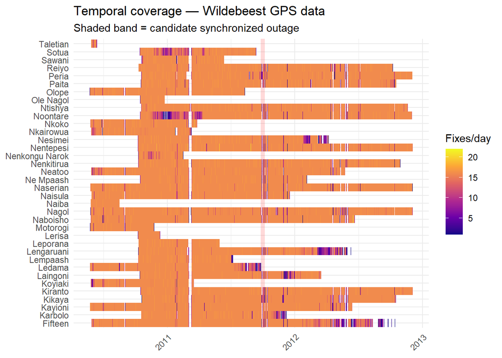

```r
# Setup a blank graph with all indiviudals
p <- WB.mv2 %>%
  as_tibble() %>%
  mutate(date = as_date(timestamp)) %>%
  count(individual_local_identifier, date) %>%
  ggplot(aes(x = date, y = individual_local_identifier, fill = n))

# Create a rectangular to place on the graph if a synchronized outage window occurred
if (!is.na(outage_start)) { # Only include if a system-wide outage occurred (if outage_start is null, do nothing)
  p <- p +
    annotate("rect",
             xmin = as_date(outage_start), xmax = as_date(outage_end),
             ymin = -Inf, ymax = Inf,
             fill = "red", alpha = 0.15)
}

# Graph the number of fixes collected over time for each animal
p +
  geom_tile() +
  scale_fill_viridis_c(name = "Fixes/day", option = "plasma") +
  labs(title = "Temporal coverage — Wildebeest GPS data",
       subtitle = if (!is.na(outage_start)) "Shaded band = candidate synchronized outage" else NULL,
       x = NULL, y = NULL) +
  theme_minimal() +
  theme(axis.text.x = element_text(angle = 45, hjust = 1)) #tilt the labels on the axis
```

> Based on this graph, there seems to be two system-wide outages, one that we identified in red and another in early 2011 that impacts nearly every individual.

## 5. Graph the Data Collected

Before doing any cleaning or analysis, **always** visualize your data on a map. This is the fastest way to spot obvious errors — locations in places where the should not be (i.e., a position in the ocean for a terrestrial mammal), impossible coordinates, or fixes far outside the study area. The `mapview` package provides tools that allow for interactive mapping. To do so, we need to first convert the object to a “Simple Features” object (`sf`).

The [sf](https://search.r-project.org/CRAN/refmans/sf/html/sf-package.html) class is an extension of a dataframe. Essentially, [sf](https://search.r-project.org/CRAN/refmans/sf/html/sf-package.html) objects can be treated as dataframes that also contain spatial data, as opposed to spatial data that may or may not also contain data frames. This enables [sf](https://search.r-project.org/CRAN/refmans/sf/html/sf-package.html) objects to fit within the [tidyverse](https://cran.r-project.org/web/packages/tidyverse/index.html) workflow, making it possible to manipulate them with the [dplyr](https://cran.r-project.org/web/packages/tidyverse/index.html) commands we used previously.

[figure not shown]

Artwork by [Allison Horst](https://allisonhorst.com/allison-horst)

```r
# Convert to sf object
WB.sf <- st_as_sf(as.data.frame(WB.mv2))

# Create graph, plotting a subset of the data for speed
WB.sf %>%
  slice_sample(n = 2000) %>%    # random subset of 2000 points
  mapview(zcol = "individual_local_identifier",
          layer.name = "Individual",
          cex = 2,
          alpha = 0.7)
```

[interactive chart not shown]

> **Question:** Do all points fall within the expected study area? Are there any obvious outliers far from the main cluster? Do individual clusters seem reasonable for wildebeest?

## 6. Save the Result

Save the two files (WB.mv2, WB.sf) we have been working with for future exercises.

```r
save(WB.mv2, WB.sf, file = "Data/WB_raw.rdata")
cat("Saved WB.mv2 —", n_distinct(mt_track_id(WB.mv2)), "animals,", nrow(WB.mv2), "fixes\n")
```

```
## Saved WB.mv2 — 36 animals, 276706 fixes
```

# Exercise: Apply to your own data

Now that you have uploaded and manipulated the wildebeest dataset in [R](https://cran.r-project.org/), adapt the code with your own data. Use [Movebank](https://www.movebank.org/) to download an available dataset or upload your data directly using `read_csv()`. Please do the following:

1. If you are pulling data from [Movebank](https://www.movebank.org/), use `movebank_download_study()` to download it. Run `n_distinct(mt_track_id())`, `mt_track_data()`, and create an individual summary table.
2. If you are importing data from a .csv, use `mt_as_move2()`. Make sure your timestamp column is parsed correctly — check the `class()` of your object and confirm that the timestamp column is formatted as `POSIXct()`.
3. Run the temporal coverage heatmap and quickly map your own data.

**Useful questions to answer for your own dataset:**

- How many individuals were imported? How long was each individual tracked?
- What is the sampling interval of your data? Is it regularly sampled?
- Are there any obvious spatial outliers? Do you notice any gaps or suspicious points?
- What patterns do you notice?

# Key functions reference

| Function | Package | Purpose |
| --- | --- | --- |
| `movebank_store_credentials()` | `move2` | Manage authentication |
| `movebank_download_study()` | `move2` | Download a complete Movebank study by ID or name |
| `mt_as_move2()` | `move2` | Convert sf, data.frame, ctmm telemetry, amt track_xyt, or Move/MoveStack objects into `move2` object |
| `mt_track_data()` | `move2` | Access or modify track‑level attributes |
| `n_distinct()` | `dplyr` | Counts the number of unique/distinct combinations in a set of one or more vectors |
| `class()` | `base` | Generic function to return the attribute of the file |
| `gtsave()` | `gt` | Saves a `gt` formatted table to .html format |
| `st_as_sf()` | `sf` | Converts a data.frame to a `sf` object, maintaining the data.frame but making the data spatial with geographic coordinates. Required for mapping or displaying data spatially |
| `slice_sample()` | `dplyr` | Subsets a sample of rows in a data.frame or tibble |

*Next:* **Module 2 — Data Cleaning.** Now that we have imported our data, we’ll begin steps to clean the dataset for analysis.